# SAT Scores in New York City

This notebook will take a look at SAT Scores from several high schools in New York City along with demographic, geogrphic and other information about the schools.

After reading in, preparing and combining multiple data sets about high schools folowing questions can be discussed:

- What variables have the biggest influence (in terms of correlation) on the total SAT scores?
- Are there significant differences between districts/boroughs?
- Is demographic information important?
- Can a ranking of the schools be explained by demographic or geographic information?
- Are the SAT fair? Concerning the allegations about the SAT being unfair to certain racial groups or biased by gender?

### NOTE

This analysis of SAT scores serves exclusively as a descriptive analysis. Everything that is computed with the data is used to gain some informative insights from and for the current data only. The analysis should not be used as a predictive. Conclusions about future data can only be carefully suggested.

## The Data

The base of this little project will be a data set about SAT scores and a data set which contains information about each high school. Such as the school name, the address, ell-programs, school type and others. Both data sets can be downloaded from the web site: data.cityofnewyork.us.

### Additional Data

To enhance the investigation on SAT scores supplementing data sets are taken into account. All the following data sets can also be downloaded from this web site: data.cityofnewyork.us.

- Math Test Results; A data set about the New York State Mathematics Test for grades 3-8.
- Class Size; This data set contains information about class sizes. The average class size for each school, each program type and grade was carried out into this data set.
- AP Test Results; This data set contains the New York City school level College Board AP results for 2010.
- Graduation Outcome; A data set about the cohorts of 2001 through 2006 (classes of 2005 through 2010). The cohort consists of all students who first entered 9th grade in a given school year (e.g., the cohort of 2006 entered 9th grade in the 2006-2007 school years). Graduates are defined as those students earning either a Local or Regents diploma.
- Demographics; Annual school accounts of NYC public school student populations served by grade, special programs, ethnicity, gender and Title I funded programs.
- School Survey; Survey results provide insight into a school’s learning environment and contribute a measure of diversification that goes beyond test scores on the Progress Report. Survey questions assess the community’s opinions on academic expectations, communication, engagement, and safety and respect. School leaders can use survey results to better understand their own school’s strengths and target areas for improvement.
- School Attendance; DOE attendance and enrollment statistics broken down by school district

## Read in and Prepare all the Data for Combination

Each school in New York City has a unique identification code called DBN, District Borough Number. So the data sets can be merged based on this DBN. First read in the data.

```r
sat_results <- read.csv(file='~/education/SAT_Results.csv', header=TRUE)
ap_results <- read.csv(file='~/education/AP_Results.csv', header=TRUE, sep=",")
math_results <- read.csv(file='~/education/Math_Results.csv', header=TRUE)
graduation <- read.csv(file='~/education/graduation.csv', header=TRUE)
demographics <- read.csv(file='~/education/demographics.csv', header=TRUE)
attendance <- read.csv(file='~/education/attendance.csv', header=TRUE)
class_size <- read.csv(file='~/education/class_size.csv', header=TRUE)
hs_directory <- read.csv(file='~/education/hs_directory.csv', header=TRUE)
colnames(hs_directory)[1] <- "DBN"
```

All the data sets contain a column with the DBN except the *class_size* data set and the *attendance* data set, where the information is given as an average for each school district in New York City. The data set called *class_size* has no specific column with the DBN, but it can be determined by combining the columns CSD, Borough and School Code.

```r
head(class_size)
```

```
##   CSD BOROUGH SCHOOL_CODE               SCHOOL_NAME GRADE PROGRAM_TYPE
## 1   1       M        M015 P.S. 015 Roberto Clemente    0K       GEN ED
## 2   1       M        M015 P.S. 015 Roberto Clemente    0K          CTT
## 3   1       M        M015 P.S. 015 Roberto Clemente    01       GEN ED
## 4   1       M        M015 P.S. 015 Roberto Clemente    01          CTT
## 5   1       M        M015 P.S. 015 Roberto Clemente    02       GEN ED
## 6   1       M        M015 P.S. 015 Roberto Clemente    02          CTT
##   CORE_SUBJECT CORE_COURSE SERVICE_CATEGORY
## 1            -           -                -
## 2            -           -                -
## 3            -           -                -
## 4            -           -                -
## 5            -           -                -
## 6            -           -                -
##   NUMBER_OF_STUDENTS_PER_SEATS_FILLED NUMBER_OF_SECTIONS
```

[output cut: 20 more lines]

```r
class_size <- within(class_size, DBN <- paste(CSD, SCHOOL_CODE, sep=""))
head(class_size[,c("DBN", "CSD", "BOROUGH", "SCHOOL_CODE", "SCHOOL_NAME")])
```

```
##     DBN CSD BOROUGH SCHOOL_CODE               SCHOOL_NAME
## 1 1M015   1       M        M015 P.S. 015 Roberto Clemente
## 2 1M015   1       M        M015 P.S. 015 Roberto Clemente
## 3 1M015   1       M        M015 P.S. 015 Roberto Clemente
## 4 1M015   1       M        M015 P.S. 015 Roberto Clemente
## 5 1M015   1       M        M015 P.S. 015 Roberto Clemente
## 6 1M015   1       M        M015 P.S. 015 Roberto Clemente
```

There appears to be another problem in this data set. There are several rows for each high school, for each DBN. However, the *sat_results* data set contains only one row for each DBN, for each high school. Since the SAT is typically taken by high school juniors and seniors one can restrict the GRADE field to “09-12” and the PROGRAM_TYPE field to “GEN ED” (General Education).

```r
levels(class_size$GRADE)
```

```
##  [1] ""        "01"      "02"      "03"      "04"      "05"      "06"
##  [8] "07"      "08"      "09"      "09-12"   "0K"      "0K-09"   "MS Core"
```

```r
class_size <- class_size[class_size$GRADE == "09-12",]
class_size <- class_size[class_size$PROGRAM_TYPE == "GEN ED",]
head(class_size)
```

```
##     CSD BOROUGH SCHOOL_CODE                                   SCHOOL_NAME
## 226   1       M        M292 Henry Street School for International Studies
## 227   1       M        M292 Henry Street School for International Studies
## 228   1       M        M292 Henry Street School for International Studies
## 229   1       M        M292 Henry Street School for International Studies
## 230   1       M        M292 Henry Street School for International Studies
## 232   1       M        M292 Henry Street School for International Studies
##     GRADE PROGRAM_TYPE CORE_SUBJECT        CORE_COURSE SERVICE_CATEGORY
## 226 09-12       GEN ED      ENGLISH          English 9                -
## 227 09-12       GEN ED      ENGLISH         English 10                -
## 228 09-12       GEN ED      ENGLISH         English 11                -
## 229 09-12       GEN ED      ENGLISH         English 12                -
## 230 09-12       GEN ED         MATH Integrated Algebra                -
## 232 09-12       GEN ED         MATH           Geometry                -
##     NUMBER_OF_STUDENTS_PER_SEATS_FILLED NUMBER_OF_SECTIONS
```

[output cut: 20 more lines]

There are still multiple rows left for each high school. So to obtain only one value for each school (DBN), the values are grouped and aggregated. For each school there is only one value for the average class size available. Before aggregating the values, all non-numeric columns are removed, since those cannot be aggregated.

```r
class_size <- subset(class_size, select = c(DBN, GRADE, PROGRAM_TYPE, NUMBER_OF_STUDENTS_PER_SEATS_FILLED, NUMBER_OF_SECTIONS, AVERAGE_CLASS_SIZE, SIZE_OF_SMALLEST_CLASS, SIZE_OF_LARGEST_CLASS))

class_size_unique <- class_size %>% group_by(DBN, GRADE, PROGRAM_TYPE) %>% summarize_each(funs(mean))
```

```
## `summarise_each()` is deprecated.
## Use `summarise_all()`, `summarise_at()` or `summarise_if()` instead.
## To map `funs` over all variables, use `summarise_all()`
```

```r
head(class_size_unique)
```

```
## # A tibble: 6 x 8
## # Groups:   DBN, GRADE [6]
##      DBN  GRADE PROGRAM_TYPE NUMBER_OF_STUDENTS_PER_SEATS_FILLED
##    <chr> <fctr>       <fctr>                               <dbl>
## 1 10X080  09-12       GEN ED                            25.00000
## 2 10X095  09-12       GEN ED                           203.00000
## 3 10X118  09-12       GEN ED                           197.00000
## 4 10X141  09-12       GEN ED                           142.41176
## 5 10X206  09-12       GEN ED                           324.00000
## 6 10X213  09-12       GEN ED                            68.61538
## # ... with 4 more variables: NUMBER_OF_SECTIONS <dbl>,
## #   AVERAGE_CLASS_SIZE <dbl>, SIZE_OF_SMALLEST_CLASS <dbl>,
## #   SIZE_OF_LARGEST_CLASS <dbl>
```

Also the demographics data set contains multiple rows for each high school. Since the investigation is based on the SAT scores in the year of 2012, only the most recent schoolyear available in the demographics data set can be picked.

```r
demographics <- demographics[demographics$schoolyear == 20112012, ]
head(demographics)
```

```
##       DBN                                             Name schoolyear
## 7  01M015 P.S. 015 ROBERTO CLEMENTE                          20112012
## 14 01M019 P.S. 019 ASHER LEVY                                20112012
## 21 01M020 PS 020 ANNA SILVER                                 20112012
## 28 01M034 PS 034 FRANKLIN D ROOSEVELT                        20112012
## 36 01M063 PS 063 WILLIAM MCKINLEY                            20112012
## 43 01M064 PS 064 ROBERT SIMON                                20112012
##    fl_percent frl_percent total_enrollment prek   k grade1 grade2 grade3
## 7                    89.4              189   13  31     35     28     25
## 14                   61.5              328   32  46     52     54     52
## 21                   92.5              626   52 102    121     87     88
## 28                   99.7              401   14  34     38     36     45
## 36                   78.9              176   18  20     30     21     31
## 43                   76.9              324   27  54     50     42     49
##    grade4 grade5 grade6 grade7 grade8 grade9 grade10 grade11 grade12
```

[output cut: 27 more lines]

The data set called *math_results* also needs to be condensed. Only select values from the year 2011 for the grade 8. From the data set called *graduation* one only needs those values where the total cohort from the year 2006 is available.

```r
math_results <- math_results[math_results$Year == 2011,]
math_results <- math_results[math_results$Grade == "8",]
head(math_results)
```

```
##        DBN Grade Year     Category Number_Tested Mean_Scale_Score Level_1
## 112 01M034     8 2011 All Students            48              646      15
## 281 01M140     8 2011 All Students            61              665       1
## 347 01M184     8 2011 All Students            49              727       0
## 389 01M188     8 2011 All Students            49              658      10
## 412 01M292     8 2011 All Students            49              650      15
## 434 01M301     8 2011 All Students            76              663      11
##     Level_1_perc Level_2 Level_2_perc Level_3 Level_3_perc Level_4
## 112        31.3%      22        45.8%      11        22.9%       0
## 281         1.6%      43        70.5%      17        27.9%       0
## 347           0%       0           0%       5        10.2%      44
## 389        20.4%      26        53.1%      10        20.4%       3
## 412        30.6%      25          51%       7        14.3%       2
## 434        14.5%      39        51.3%      23        30.3%       3
##     Level_4_perc Level_3_4 Level_3_4_perc
## 112           0%        11          22.9%
## 281           0%        17          27.9%
## 347        89.8%        49           100%
## 389         6.1%        13          26.5%
## 412         4.1%         9          18.4%
## 434         3.9%        26          34.2%
```

```r
graduation <- graduation[graduation$Cohort == "2006",]
graduation <- graduation[graduation$Demographic == "Total Cohort",]
head(graduation)
```

```
##     Demographic    DBN                           School_Name Cohort
## 4  Total Cohort 01M292 HENRY STREET SCHOOL FOR INTERNATIONAL   2006
## 11 Total Cohort 01M448   UNIVERSITY NEIGHBORHOOD HIGH SCHOOL   2006
## 18 Total Cohort 01M450            EAST SIDE COMMUNITY SCHOOL   2006
## 25 Total Cohort 01M509               MARTA VALLE HIGH SCHOOL   2006
## 32 Total Cohort 01M515 LOWER EAST SIDE PREPARATORY HIGH SCHO   2006
## 39 Total Cohort 01M539 NEW EXPLORATIONS INTO SCIENCE  TECHNO   2006
##    Total_Cohort Total_Grads_n Total_Grads_per_of_cohort Total_Regents_n
## 4            78            43                     55.1%              36
## 11          124            53                     42.7%              42
## 18           90            70                     77.8%              67
## 25           84            47                       56%              40
## 32          193           105                     54.4%              91
## 39           46            46                      100%              46
##    Total_Regents_perc_of_cohort Total_Regents_perc_of_grads
```

[output cut: 41 more lines]

## Adding in the Surveys

The data set on student, parent, and teacher surveys about the quality of schools is also a potentially interesting data set to look at. The surveys include information about the perceived safety of each school, academic standards, and more.

First the data sets are read in and then combined to on single set called *survey*.

There are two school-level data files from the 2011 NYC School Survey available. School-level data is available in one file for all community schools (file name: survey.csv) and one file for all District 75 schools (file name: survey_75.csv). These files display one line of information for each school, by DBN, that includes the response rate for each school, the number of surveys submitted, the size of the eligible survey population at each school, question scores, the percentage of responses selected, and the count of responses selected.

Along with the data there can be a data dictionary file downloaded. Based on this file any extraneous columns can be removed.

```r
survey_gened <- read.csv2(file='C:/Users/Anna Sofia/Documents/Portfolio/education/survey.csv', header=TRUE)
survey_75 <- read.csv2(file='C:/Users/Anna Sofia/Documents/Portfolio/education/survey_75.csv', header=TRUE)

survey_all <- merge(survey_gened, survey_75, by="dbn", all = TRUE)
colnames(survey_all)[1] <- "DBN"

survey <- subset(survey_all, select = c(DBN, rr_s.x, rr_t.x, rr_p.x, N_s.x, N_t.x, N_p.x, saf_p_11.x, com_p_11.x, eng_p_11.x, aca_p_11.x, saf_t_11.x, com_t_11.x, eng_t_11.x, aca_t_11.x, saf_s_11.x, com_s_11.x, eng_s_11.x, aca_s_11.x, saf_tot_11.x, com_tot_11.x, eng_tot_11.x, aca_tot_11.x)) #23
```

```r
survey_gened <- read.csv2(file='~/education/survey.csv', header=TRUE)
survey_75 <- read.csv2(file='~/education/survey_75.csv', header=TRUE)

# merge surveys
survey_all <- merge(survey_gened, survey_75, by="dbn", all = TRUE)
colnames(survey_all)[1] <- "DBN"

# remove extraneous columns
survey <- subset(survey_all, select = c(DBN, rr_s.x, rr_t.x, rr_p.x, N_s.x, N_t.x, N_p.x, saf_p_11.x, com_p_11.x, eng_p_11.x, aca_p_11.x, saf_t_11.x, com_t_11.x, eng_t_11.x, aca_t_11.x, saf_s_11.x, com_s_11.x, eng_s_11.x, aca_s_11.x, saf_tot_11.x, com_tot_11.x, eng_tot_11.x, aca_tot_11.x)) #23
```

## Computing new Variables

Rather than the individual SAT scores the total SAT score is interesting for this investigation. Unavailable scores are marked with an “s”. So converting the scores into integers has to happen after some data manipulation. First all unavailable values (“s”) are determined and marked as *NA*. Then the scores can be converted to integers. The same needs to be done for the ap_results data set.

For the question of possible differences between districts or borough, those variables are determined by reading the district and borough number out of the DBN.

```r
summary(sat_results)
```

```
##       DBN
##  01M292 :  1
##  01M448 :  1
##  01M450 :  1
##  01M458 :  1
##  01M509 :  1
##  01M515 :  1
##  (Other):471
##                                                                          SCHOOL_NAME
##  47 THE AMERICAN SIGN LANGUAGE AND ENGLISH SECONDARY SCHOOL                    :  1
##  A. PHILIP RANDOLPH CAMPUS HIGH SCHOOL                                         :  1
##  ABRAHAM LINCOLN HIGH SCHOOL                                                   :  1
##  ACADEMY FOR CAREERS IN TELEVISION AND FILM                                    :  1
##  ACADEMY FOR COLLEGE PREPARATION AND CAREER EXPLORATION: A COLLEGE BOARD SCHOOL:  1
##  ACADEMY FOR CONSERVATION AND THE ENVIRONMENT                                  :  1
##  (Other)                                                                       :471
##  Num_of_SAT_Test_Takers SAT_Critical_Reading_Avg_Score SAT_Math_Avg_Score
##  s      : 56            s      : 56                    s      : 56
##  54     : 10            367    :  8                    385    :  9
##  48     :  8            370    :  8                    364    :  8
##  72     :  8            384    :  8                    371    :  8
##  9      :  8            398    :  8                    381    :  8
##  29     :  7            363    :  7                    391    :  8
##  (Other):380            (Other):382                    (Other):380
##  SAT_Writing_Avg_Score
##  s      : 56
##  368    :  9
##  370    :  9
##  359    :  8
##  394    :  8
##  351    :  7
##  (Other):380
```

```r
# missing observations are marked as "s".
# indicate missing values as NA
sat_results[sat_results$Num_of_SAT_Test_Takers == "s", "Num_of_SAT_Test_Takers"] <- NA
sat_results[sat_results$SAT_Critical_Reading_Avg_Score == "s", "SAT_Critical_Reading_Avg_Score"] <- NA
sat_results[sat_results$SAT_Math_Avg_Score == "s", "SAT_Math_Avg_Score"] <- NA
sat_results[sat_results$SAT_Writing_Avg_Score == "s", "SAT_Writing_Avg_Score"] <- NA

# now the values can be converted to numeric
sat_results <- within(sat_results, {
                      Num_of_SAT_Test_Takers <- as.numeric(as.character(Num_of_SAT_Test_Takers))
                      SAT_Critical_Reading_Avg_Score <- as.numeric(as.character(SAT_Critical_Reading_Avg_Score))
                      SAT_Math_Avg_Score <- as.numeric(as.character(SAT_Math_Avg_Score))
                      SAT_Writing_Avg_Score <- as.numeric(as.character(SAT_Writing_Avg_Score)) })

# compute the total SAT score
sat_results <- within(sat_results,
                      SAT_Total_Score <- SAT_Critical_Reading_Avg_Score + SAT_Math_Avg_Score + SAT_Writing_Avg_Score)

# determine District and Borough out of the DBN
sat_results <- within(sat_results, {
  BOROUGH <- as.factor(substr(DBN, start = 3, stop = 3))
  DISTRICT <- as.factor(substr(DBN, start = 1, stop = 2))
})
```

## Combining all the Data Sets

Now all data sets can be combined into one. Based on the DBN all data sets are joined.

```r
merge_1 <- merge(math_results, survey, by="DBN")
merge_2 <- merge(merge_1, ap_results, by="DBN", all=TRUE)
merge_3 <- merge(merge_2, class_size_unique, by="DBN")
merge_4 <- merge(merge_3, demographics, by="DBN")
merge_5 <- merge(merge_4, graduation, by="DBN", all=TRUE)
merge_6 <- merge(merge_5, hs_directory, by="DBN")
sat_nyc <- merge(merge_6, sat_results, by="DBN", all=TRUE)
```

## Missing SAT Scores

The main purpose of this notebook is to investigate SAT results, so it makes not much sense to include data without SAT results. Maybe for other questions, which are not regarding the SAT results on the first glance, other data without matching SAT scores is important. Here the analysis is emphasized on the SAT scores. So all schools without those are removed from the data set.

One could impute missing SAT scores with an average or something else, but replacing missing values with the mean of a column is statistical malpractice and not really necessary here, since there are only 56 missing values. So after removing the NA’s entirely there are still 421 observations from the before 477 left.

```r
sat_na_omit <- na.omit(sat_results)
sat_nyc_na_omit <- merge(merge_6, sat_na_omit, by="DBN", all.y=TRUE)
nrow(sat_results)
```

```
## [1] 477
```

```r
nrow(sat_na_omit)
```

```
## [1] 421
```

Now there is one single data set which contains SAT scores as well as all the additional information. For each school, each DBN, all values are carried out in one row in the data set.

The combined data set can now be investigated. Following questions are discussed: * What variables have the biggest inlfuence (in terms of correlation) on the total SAT scores? * Are there significant differences between districts/boroughs? * Are demographic information important? * Can a ranking of the schools be explained by demographic or geographic information? * Are the SAT fair? Concerning the allegations about the SAT being unfair to certain racial groups or gender biased?

```r
summary(sat_nyc_na_omit$SAT_Total_Score)
```

```
##    Min. 1st Qu.  Median    Mean 3rd Qu.    Max.
##     887    1102    1169    1208    1257    2096
```

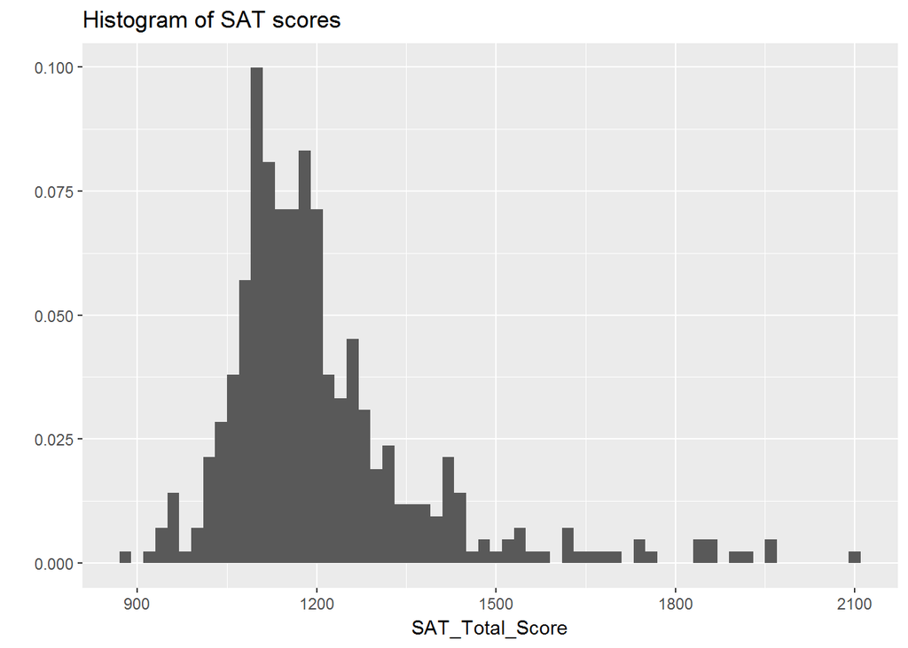

```r
ggplot(sat_nyc_na_omit, aes(x=SAT_Total_Score)) +
  geom_histogram(aes(y=..count../sum(..count..)), binwidth = 20) +
  ggtitle("Histogram of SAT scores") + ylab("")
```

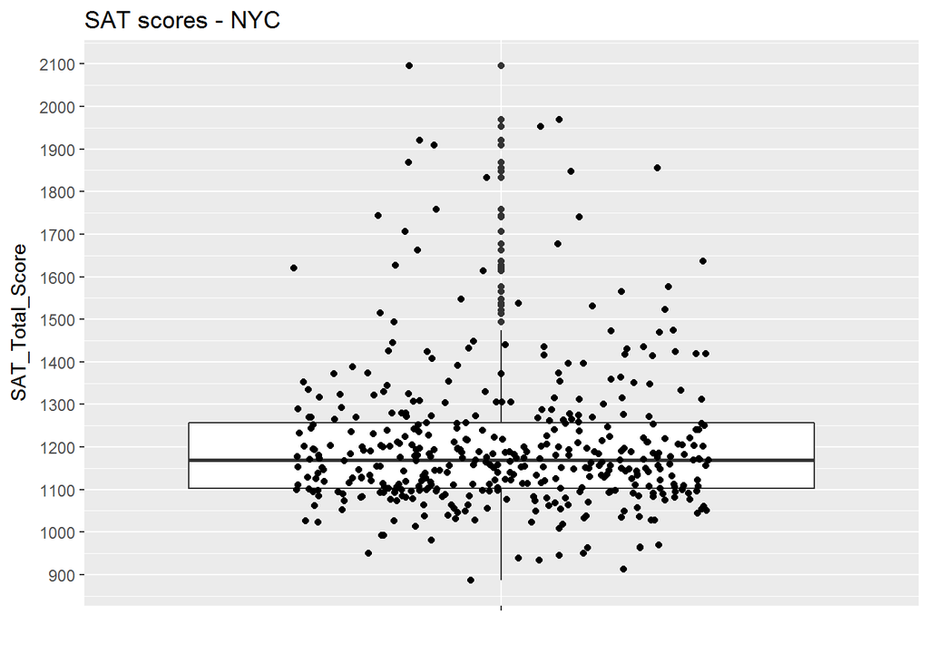

```r
ggplot(sat_nyc_na_omit, aes(x="", y=SAT_Total_Score)) +
  geom_boxplot() + geom_jitter(width=0.25) + scale_y_continuous(breaks = seq(from=800, to=2200, by=100)) + ggtitle("SAT scores - NYC") + xlab("")
```

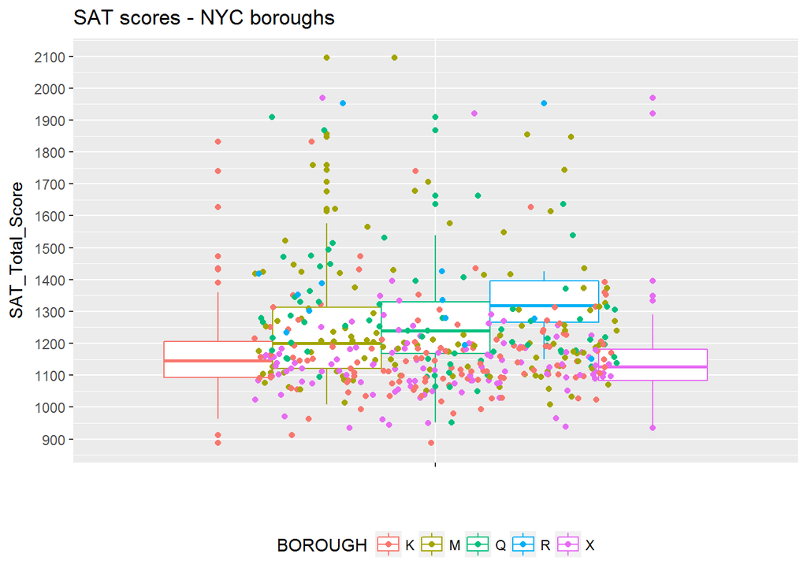

```r
ggplot(sat_nyc_na_omit, aes(x="", y=SAT_Total_Score, colour=BOROUGH)) +
  geom_boxplot() + geom_jitter(width=0.25) + scale_y_continuous(breaks = seq(from=800, to=2200, by=100)) + ggtitle("SAT scores - NYC boroughs") + xlab("") + theme(legend.position="bottom")
```

Let’s take a look at where the differences in the average scores might come from. Looking at the scores again but colored according to the school type there is an interesting phenomenon going on. The schools with the highest SAT scores are so called Specialized Schools. This does not surprise since those schools were established especially to serve the needs of academically and artistically gifted children.

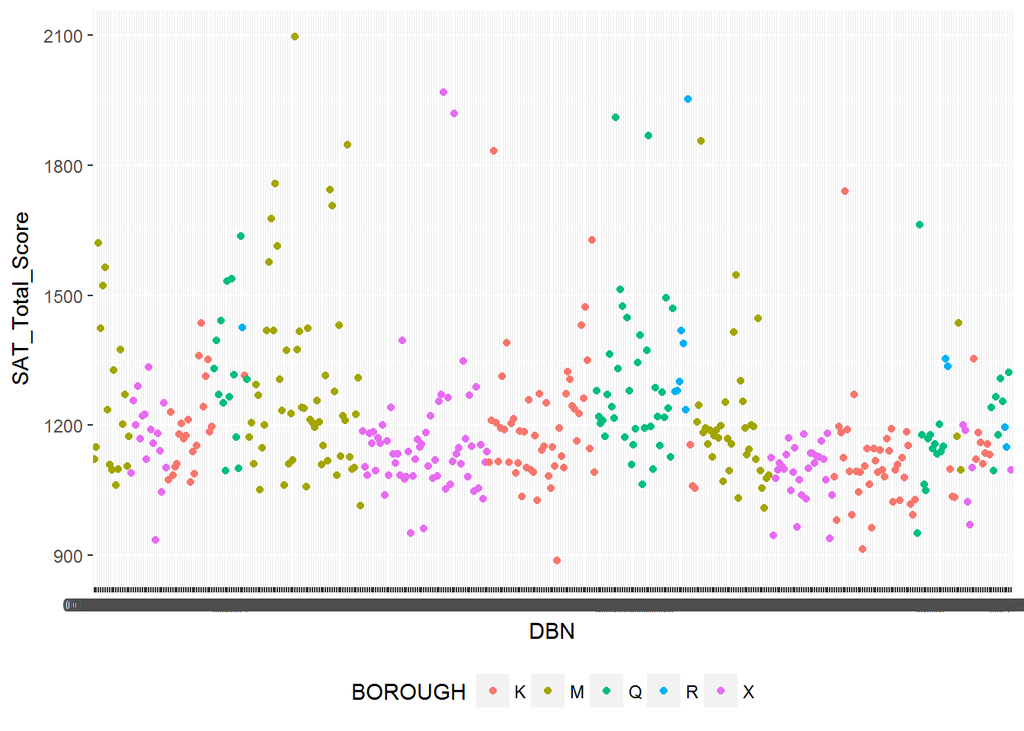

```r
ggplot(sat_nyc_na_omit, aes(x=DBN, y=SAT_Total_Score, colour=BOROUGH)) +
  geom_point() + theme(legend.position="bottom")
```

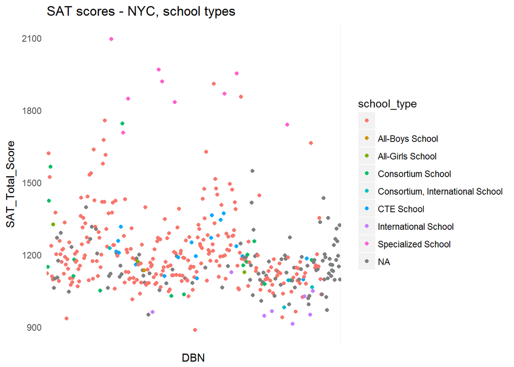

```r
ggplot(sat_nyc_na_omit, aes(x=DBN, y=SAT_Total_Score, colour=school_type)) +
  geom_point() + ggtitle("SAT scores - NYC, school types") + theme(axis.ticks = element_blank(), axis.text.x = element_blank())
```

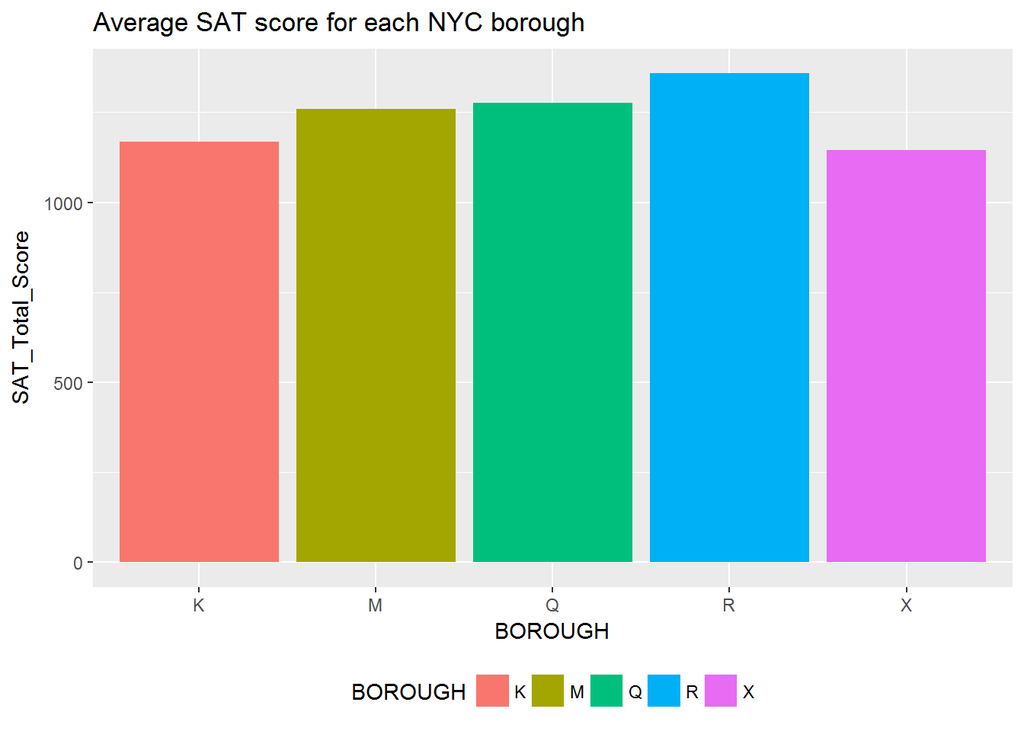

```r
ggplot(sat_nyc_na_omit, aes(x=BOROUGH, y=SAT_Total_Score, fill=BOROUGH)) +
  stat_summary(fun.y="mean", geom="bar") +
  ggtitle("Average SAT score for each NYC borough") + theme(legend.position="bottom")
```

## Correlations

Let’s now take a closer look at the individual variables that might have a correlation with the SAT scores. First only numeric variables are taken into account, such as the percentage of ELL students at a school.

If a high schooler indicates that a language other than English is spoken in his/her home, the child is given the New York State Identification Test for English Language Learners (NYSITELL), which is designed to determine English language proficiency. Students who score below a State determined level on the assessment are identified as ELLs, and are therefore entitled to ELL programs and services.

Attending school while not speaking the teaching language proficiently is considered to be difficult, therefore a negative correlation between ell_percent and SAT scores is expected.

```r
# select subset of variables to investigate
sat_corr <- subset(sat_nyc_na_omit, select = c(SAT_Total_Score, Num_of_SAT_Test_Takers,
                                               Location.1, ell_programs, school_type,
                                               total_students, borough, Number_Tested,
                                               rr_s.x, rr_t.x, rr_p.x,
                                               saf_p_11.x,saf_t_11.x, saf_s_11.x, com_p_11.x,
                                               com_t_11.x, com_s_11.x, eng_p_11.x, eng_t_11.x,
                                               eng_s_11.x, aca_p_11.x, aca_t_11.x, aca_s_11.x,
                                               saf_tot_11.x, com_tot_11.x, eng_tot_11.x,
                                               aca_tot_11.x,
                                               APTestTakers, TotalExamsTaken,
                                               NumberExamsScores345, AVERAGE_CLASS_SIZE,
                                               total_enrollment, ell_percent,
                                               sped_percent, asian_per, black_per, hispanic_per,
                                               white_per, male_per, female_per, Total_Cohort))
```

```r
isnum <- sapply(sat_corr, is.numeric)
sat <- "SAT_Total_Score"
num_var <- setdiff(names(sat_corr)[isnum], sat)

# Linear relationships between any (numeric) variable and the total SAT score.
# use option piarwise complete, otherwise every row with at least one single NA would be removed
corrs <- cor(sat_corr[num_var], sat_corr[sat], use="pairwise.complete.obs")
corrs
```

```
##                        SAT_Total_Score
## Num_of_SAT_Test_Takers      0.48263871
## total_students              0.41094444
## Number_Tested               0.21079355
## rr_s.x                      0.47286570
## rr_t.x                     -0.35292363
## rr_p.x                      0.21259646
## saf_p_11.x                  0.40386804
## saf_t_11.x                  0.42976813
## saf_s_11.x                  0.36327255
## com_p_11.x                  0.10611562
## com_t_11.x                  0.13787619
## com_s_11.x                  0.22987419
## eng_p_11.x                  0.23352860
## eng_t_11.x                  0.06347434
## eng_s_11.x                  0.22719199
## aca_p_11.x                  0.26902194
## aca_t_11.x                  0.18549233
## aca_s_11.x                  0.33819545
## saf_tot_11.x                0.45476112
## com_tot_11.x                0.17852443
## eng_tot_11.x                0.18030281
## aca_tot_11.x                0.29432557
## APTestTakers                0.64490622
## TotalExamsTaken             0.63653551
## NumberExamsScores345        0.63889054
## AVERAGE_CLASS_SIZE          0.41633108
## total_enrollment            0.36692514
## ell_percent                -0.37775889
## sped_percent               -0.53378221
## asian_per                   0.65752758
## black_per                  -0.34012287
## hispanic_per               -0.43165496
## white_per                   0.61689476
## male_per                   -0.07865809
## female_per                  0.07871189
## Total_Cohort                0.32843130
```

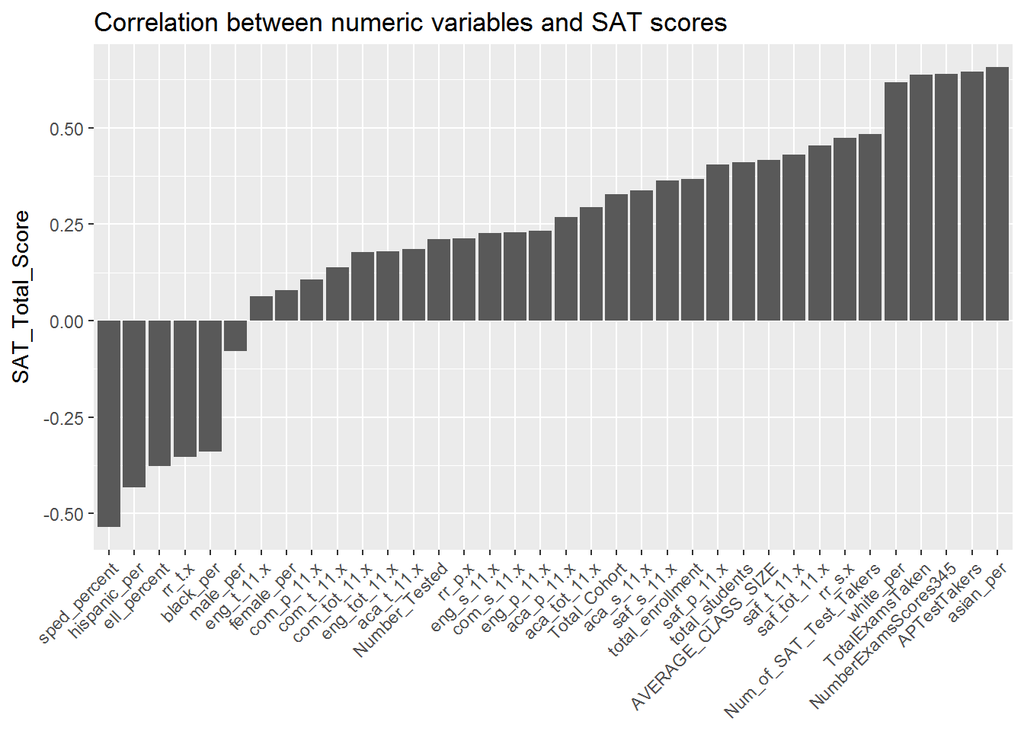

```r
ggplot(corrs, aes(x=rowname, y=SAT_Total_Score)) +
  geom_bar(stat="identity") +
  theme(axis.text.x = element_text(angle=45, hjust=1, vjust=1), axis.title.x = element_blank()) +
  ggtitle("Correlation between numeric variables and SAT scores")
```

There are several points and insights that might need to be explored.

- ell_percent correlate strongly negatively with SAT scores, as expected.
- The same states for sped_percent, the percentage of students that are eligible for special-education services correlates strongly negatively with SAT scores.
- The survey responses do not correlate highly with SAT scores, except the Student response rate and the Safety and Respects scores. It may be, however, interesting that most survey responses correlate positively with SAT scores, whereas the Teacher respond rate correlates negatively with SAT scores.
- The percentage of males correlates negatively with SAT scores, whereas the percentage of females correlates positively with SAT scores.
- It is surprising that total enrollment correlates rather positively with SAT scores, because one would think that smaller schools which could focus more on the student would have higher scores.
- It is also surprising that the number of test takers correlates quite strongly with SAT scores.
- There seems to be a strong racial inequality in SAT scores.
- The number of AP Test Takers correlates highly positively with SAT scores.

### Highly Correlated

```r
corrs[abs(corrs$SAT_Total_Score) >= 0.40, ]
```

```
##                        SAT_Total_Score                rowname
## sped_percent                -0.5337822           sped_percent
## hispanic_per                -0.4316550           hispanic_per
## saf_p_11.x                   0.4038680             saf_p_11.x
## total_students               0.4109444         total_students
## AVERAGE_CLASS_SIZE           0.4163311     AVERAGE_CLASS_SIZE
## saf_t_11.x                   0.4297681             saf_t_11.x
## saf_tot_11.x                 0.4547611           saf_tot_11.x
## rr_s.x                       0.4728657                 rr_s.x
## Num_of_SAT_Test_Takers       0.4826387 Num_of_SAT_Test_Takers
## white_per                    0.6168948              white_per
## TotalExamsTaken              0.6365355        TotalExamsTaken
## NumberExamsScores345         0.6388905   NumberExamsScores345
## APTestTakers                 0.6449062           APTestTakers
## asian_per                    0.6575276              asian_per
```

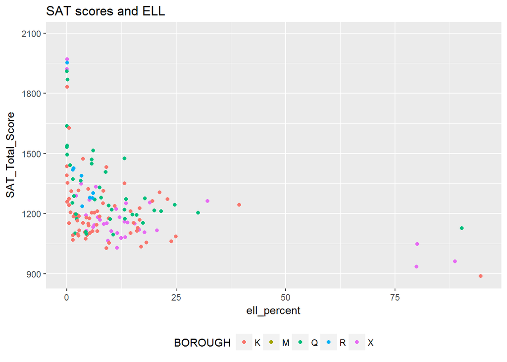

```r
ggplot(sat_nyc_na_omit, aes(x=ell_percent, y=SAT_Total_Score, colour=BOROUGH)) +
  geom_point() + ggtitle("SAT scores and ELL") + theme(legend.position="bottom")
```

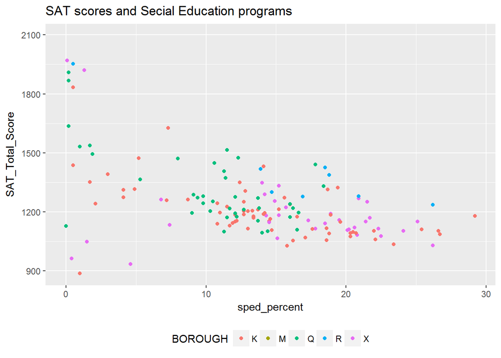

```r
ggplot(sat_nyc_na_omit, aes(x=sped_percent, y=SAT_Total_Score, colour=BOROUGH)) +
  geom_point() + ggtitle("SAT scores and Secial Education programs") +
  theme(legend.position="bottom")
```

The percentages of students that are eligible for ELL or special-education services correlate highly negatively with SAT scores. There may be an effect on the scores when there are ELL or sped students or not rather than a direct relationship between the percentage and the scores.

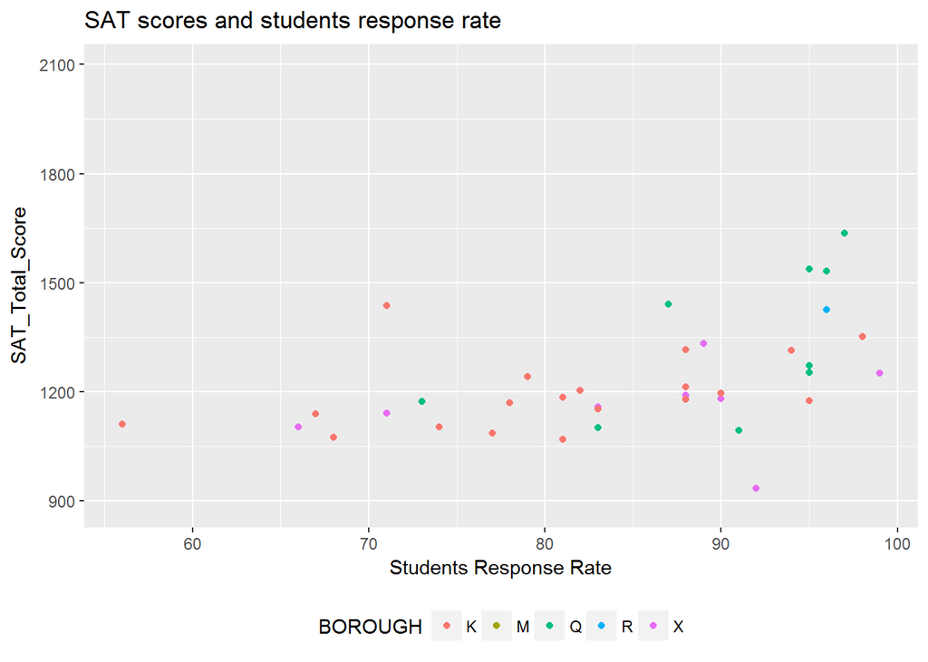

```r
ggplot(sat_nyc_na_omit, aes(x=rr_s.x, y=SAT_Total_Score, colour=BOROUGH)) +
  geom_point() + ggtitle("SAT scores and students response rate") + xlab("Students Response Rate") +
  theme(legend.position="bottom")
```

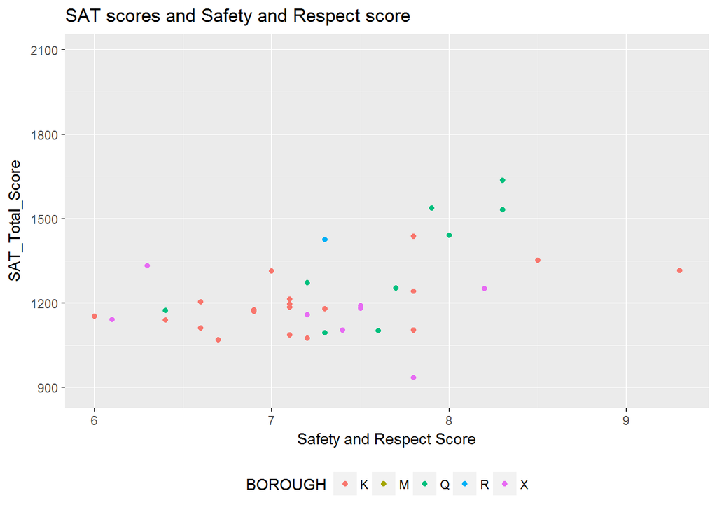

```r
ggplot(sat_nyc_na_omit, aes(x=saf_tot_11.x, y=SAT_Total_Score, colour=BOROUGH)) +
  geom_point() + ggtitle("SAT scores and Safety and Respect score") + xlab("Safety and Respect Score") +
  theme(legend.position="bottom")
```

The correlation between the student response rate and the SAT scores is quite surprising, but since there are only a few observations which can be considered as a little blurry, one might not read too much into that. On the other hand the correlation between SAT scores and the Safety and Respects scores might be explainable. If a school provides a safe and respectful learning environment, students might learn better. Especially if teachers feel safe and respected their patience and ability to teach individually might improve, which also reflect on their students.

### Exploring race and gender differences in SAT scores

One of the other angles to investigate involves gender and race and SAT scores. Looking at the percentages of males and females in each school the opposite effect also seen in the correlation can again be found in scatterplots.

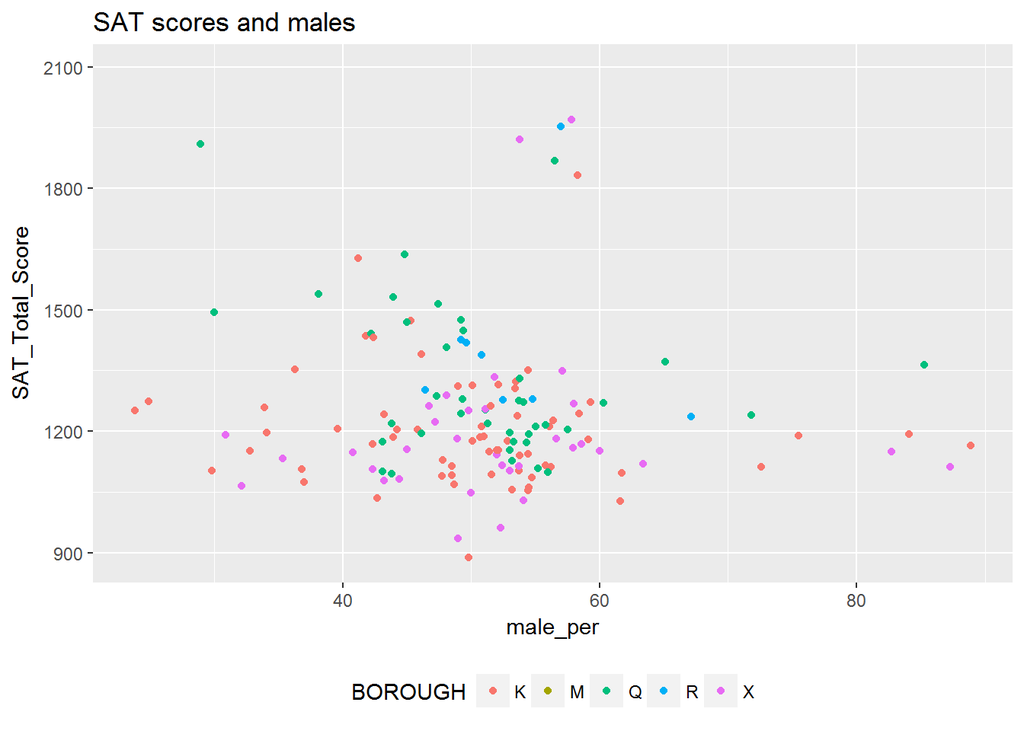

```r
ggplot(sat_nyc_na_omit, aes(x=male_per, y=SAT_Total_Score, colour=BOROUGH)) +
  geom_point() + ggtitle("SAT scores and males") + theme(legend.position="bottom")
```

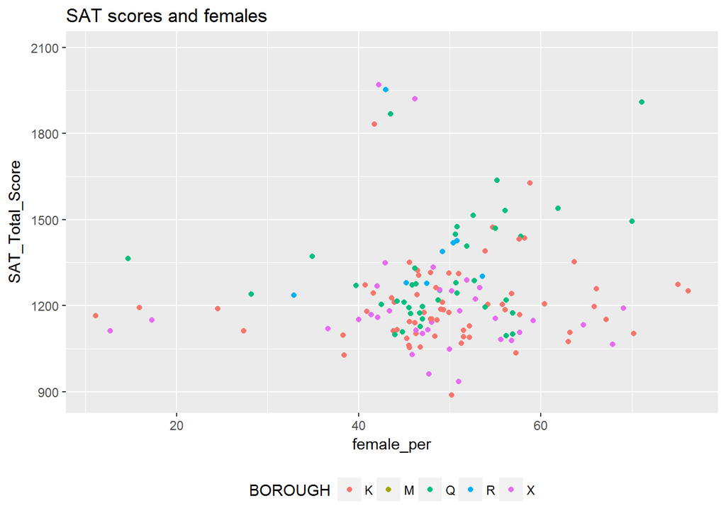

```r
ggplot(sat_nyc_na_omit, aes(x=female_per, y=SAT_Total_Score, colour=BOROUGH)) +
  geom_point() + ggtitle("SAT scores and females") + theme(legend.position="bottom")
```

One possible explanation for the positive correlation of SAT scores and percentages of females could be that schools with an extremely high percentage of females tend to be elite schools that focus on the performing arts. This likely accounts for the correlation between higher female percentages and SAT scores, and the inverse correlation between higher male percentages and lower SAT scores.

```r
head(na.omit(sat_nyc_na_omit[sat_nyc_na_omit$female_per > 65, "SCHOOL_NAME"]))
```

```
## [1] THEATRE ARTS PRODUCTION COMPANY SCHOOL
## [2] TEACHERS PREPARATORY HIGH SCHOOL
## [3] BRONX THEATRE HIGH SCHOOL
## [4] BROOKLYN HIGH SCHOOL OF THE ARTS
## [5] HIGH SCHOOL FOR PUBLIC SERVICE: HEROES OF TOMORROW
## [6] BROOKLYN SCHOOL FOR MUSIC & THEATRE
## 477 Levels: 47 THE AMERICAN SIGN LANGUAGE AND ENGLISH SECONDARY SCHOOL ...
```

One of the other angles to investigate involves race and SAT scores.

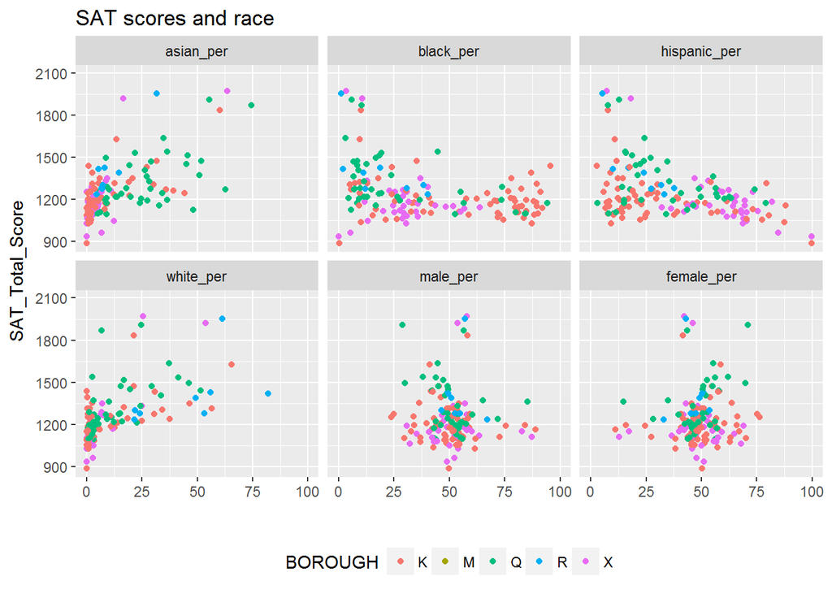

```r
sat_per <- subset(sat_nyc_na_omit, select = c(SAT_Total_Score,
                                              SAT_Math_Avg_Score,
                                              SAT_Critical_Reading_Avg_Score,
                                              SAT_Writing_Avg_Score,
                                              asian_per, black_per, hispanic_per,
                                              white_per, male_per, female_per, school_type,
                                              BOROUGH))

sat_per <- melt(sat_per, measure.vars = c("asian_per", "black_per", "hispanic_per",
                                          "white_per", "male_per", "female_per"),
                variable.name = "per")

ggplot(sat_per, aes(x=value, y=SAT_Total_Score, colour=BOROUGH)) +
  geom_point() + facet_wrap(~per) + ggtitle("SAT scores and race") +
  theme(legend.position="bottom") + xlab("")
```

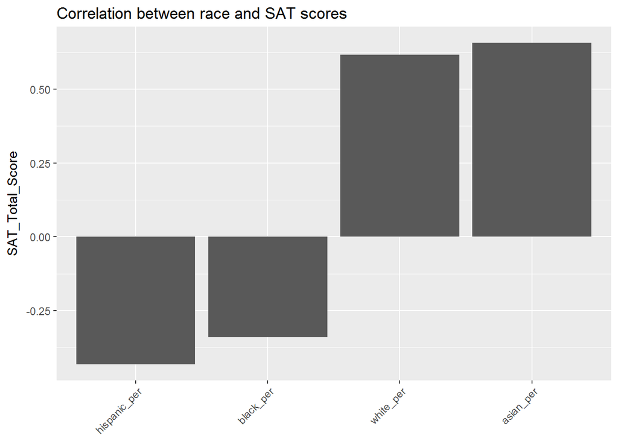

```r
corrs_race <- corrs[corrs$rowname %in% c("asian_per", "black_per", "hispanic_per", "white_per"),]

ggplot(corrs_race, aes(x=rowname, y=SAT_Total_Score)) +
  geom_bar(stat="identity") +
  theme(axis.text.x = element_text(angle=45, hjust=1, vjust=1), axis.title.x = element_blank()) +
  ggtitle("Correlation between race and SAT scores")
```

It seems that higher percentages of hispanic and black students correlate negatively with SAT scores whereas higher percentages of white and asian students correlate positively with SAT scores. For hispanic students this may be because schools with a higher percentage of hispanic students tend to also have a higher percentage of ELLs, because they might be more recent immigrants. Looking at the percentage of ELLs and hispanic students enhances this additional correlation.

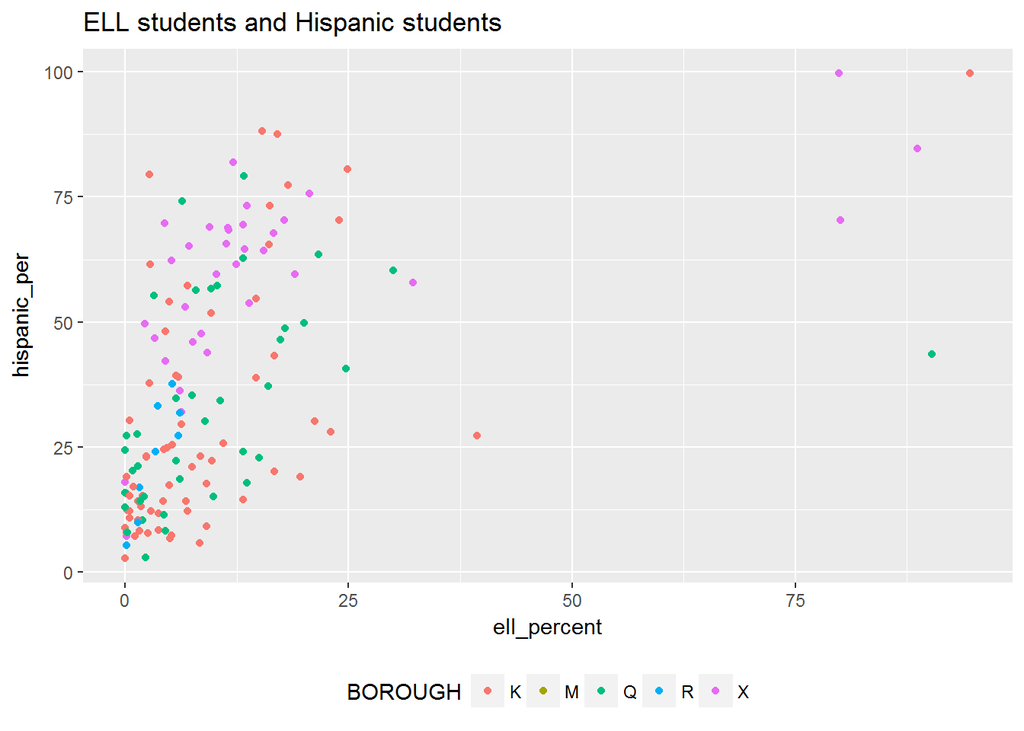

```r
ggplot(sat_nyc_na_omit, aes(x=ell_percent, y=hispanic_per, colour=BOROUGH)) + geom_point() +
  ggtitle("ELL students and Hispanic students") + theme(legend.position="bottom")
```

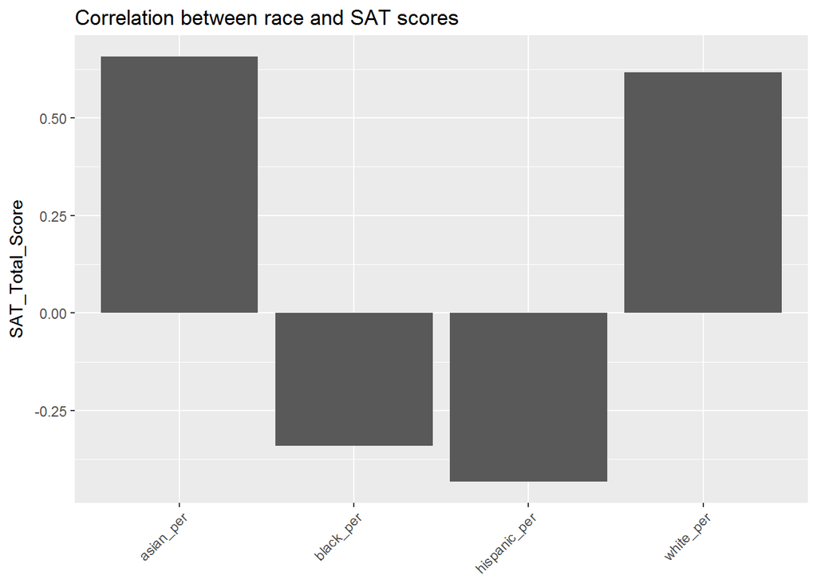

```r
corrs_race <- data.frame(cor(sat_nyc_na_omit[,c("asian_per", "black_per", "hispanic_per", "white_per")], sat_nyc_na_omit[c("SAT_Critical_Reading_Avg_Score","SAT_Math_Avg_Score", "SAT_Writing_Avg_Score", "SAT_Total_Score")], use="pairwise.complete.obs"))

ggplot(corrs_race, aes(x=rownames(corrs_race), y=SAT_Total_Score)) +
  geom_bar(stat="identity") +
  theme(axis.text.x = element_text(angle=45, hjust=1, vjust=1), axis.title.x = element_blank()) +
  ggtitle("Correlation between race and SAT scores")
```

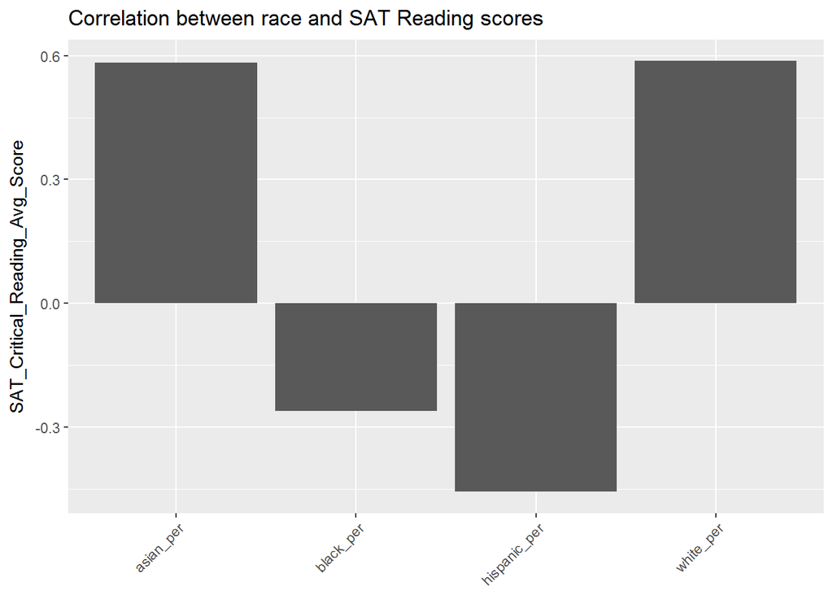

```r
ggplot(corrs_race, aes(x=rownames(corrs_race), y=SAT_Critical_Reading_Avg_Score)) +
  geom_bar(stat="identity") +
  theme(axis.text.x = element_text(angle=45, hjust=1, vjust=1), axis.title.x = element_blank()) +
  ggtitle("Correlation between race and SAT Reading scores")
```

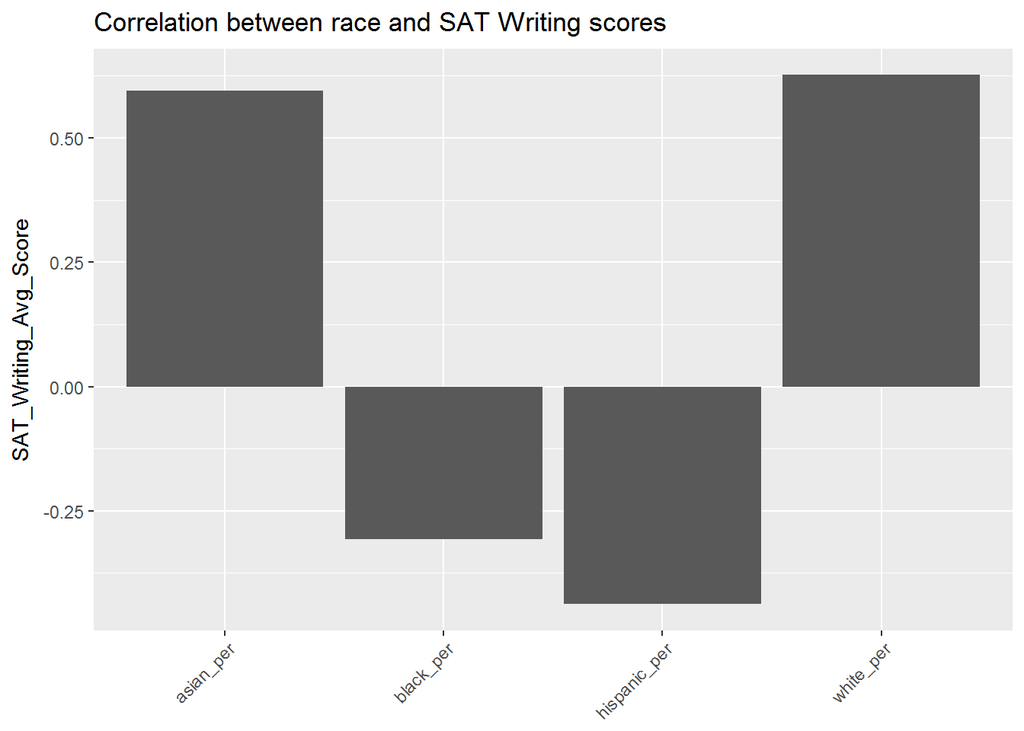

```r
ggplot(corrs_race, aes(x=rownames(corrs_race), y=SAT_Writing_Avg_Score)) +
  geom_bar(stat="identity") +
  theme(axis.text.x = element_text(angle=45, hjust=1, vjust=1), axis.title.x = element_blank()) +
  ggtitle("Correlation between race and SAT Writing scores")
```

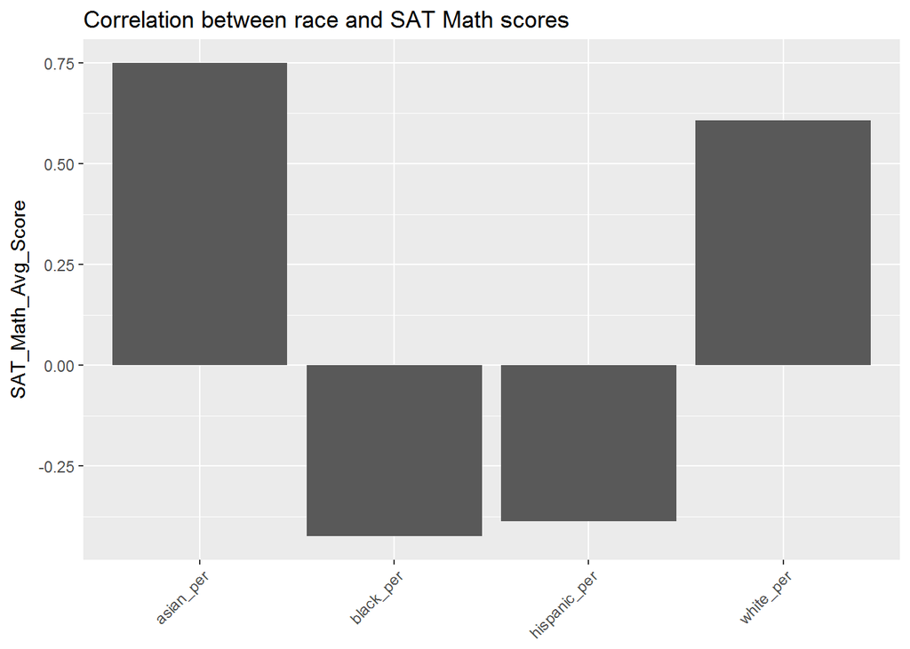

```r
ggplot(corrs_race, aes(x=rownames(corrs_race), y=SAT_Math_Avg_Score)) +
  geom_bar(stat="identity") +
  theme(axis.text.x = element_text(angle=45, hjust=1, vjust=1), axis.title.x = element_blank()) +
  ggtitle("Correlation between race and SAT Math scores")
```

### AP Scores

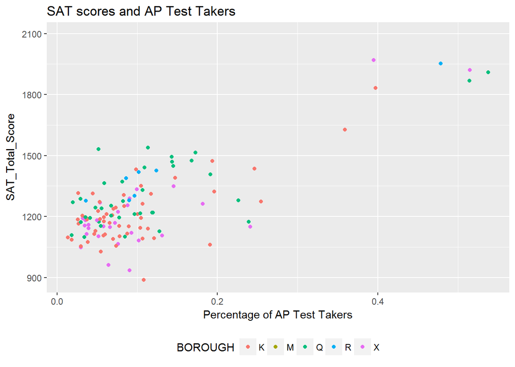

```r
ggplot(sat_nyc_na_omit, aes(x=(APTestTakers/total_enrollment), y=SAT_Total_Score, colour=BOROUGH)) + geom_point() + xlab("Percentage of AP Test Takers") + ggtitle("SAT scores and AP Test Takers") +
  theme(legend.position="bottom")
```

The quite highly positive correlation between the number of students which took an AP test and the SAT scores is worth being further investigated. When looking at the scatterplot above, one can actually see the positive correlation. However there seems to be a cluster in the right top area which may be a group of observations that are biased. All high schools which have a percentage of AP test takers higher than 30% are listed below. Those are all schools with an admission test so highly selective schools. It seems reasonable that especially those schools would have a high proportion of AP test takers. After removing those schools and computing the correlation again one can see that it has decreased. The correlation between AP test takers and SAT scores is less high. There seems to be now a little bit more variety.

```r
ind <- which(sat_nyc_na_omit$APTestTakers/sat_nyc_na_omit$total_enrollment > 0.3 )
sat_nyc_na_omit[ind, "SCHOOL_NAME"]
```

```
## [1] BRONX HIGH SCHOOL OF SCIENCE
## [2] HIGH SCHOOL OF AMERICAN STUDIES AT LEHMAN COLLEGE
## [3] BROOKLYN TECHNICAL HIGH SCHOOL
## [4] LEON M. GOLDSTEIN HIGH SCHOOL FOR THE SCIENCES
## [5] TOWNSEND HARRIS HIGH SCHOOL
## [6] QUEENS HIGH SCHOOL FOR THE SCIENCES AT YORK COLLEGE
## [7] STATEN ISLAND TECHNICAL HIGH SCHOOL
## 477 Levels: 47 THE AMERICAN SIGN LANGUAGE AND ENGLISH SECONDARY SCHOOL ...
```

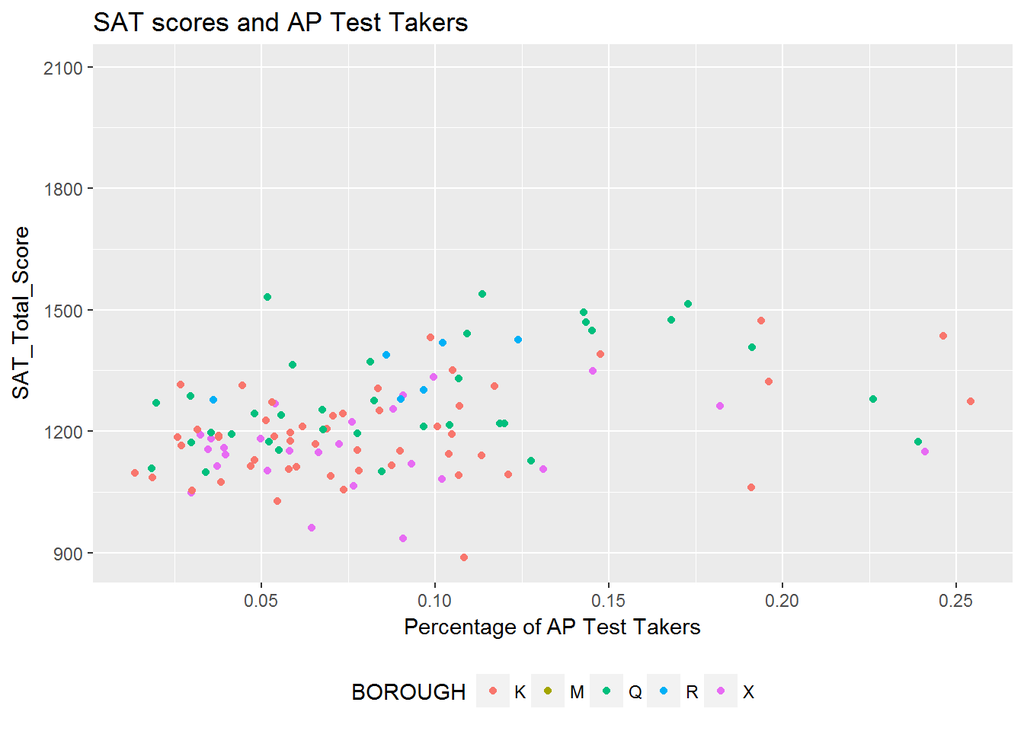

```r
ggplot(sat_nyc_na_omit[-ind, ], aes(x=(APTestTakers/total_enrollment), y=SAT_Total_Score, colour=BOROUGH)) + geom_point() + xlab("Percentage of AP Test Takers") +
  ggtitle("SAT scores and AP Test Takers") + theme(legend.position="bottom")
```

```r
ap_corr_small <- sat_nyc_na_omit[-ind,]
cor(ap_corr_small$APTestTakers, ap_corr_small$SAT_Total_Score, use = "complete.obs")
```

```
## [1] 0.5735253
```

```r
cor(sat_nyc_na_omit$APTestTakers, sat_nyc_na_omit$SAT_Total_Score, use = "complete.obs")
```

```
## [1] 0.6449062
```

Since several states use Advanced Placement data for accountability purposes and to rank high schools a critical analysis is more or less inevitable. An overview of studies gives this article [here](https://theconversation.com/pushing-students-to-take-advanced-placement-courses-does-not-help-anyone-45350). The authors also ask if legal mandates and financial incentives for AP courses are good investments of resources. They also conducted as a whole that increasing AP participation does not increase the overall academic achievement or school quality at the group (e.g., high school, racial/ethnic group, and nation) level. This led one researcher to state, “Clearly, offering AP alone will not magically turn a failing school into a successful one.”

The greatest advantages of AP programs lie in the academic achievements for those students who actually took the test.

### What can NOT be concluded

This analysis of SAT scores has shown some interesting insights which are worth to be further investigated. However, there are limits to it (like to any other data analysis). For example regarding gender and race percentages, the highly negative correlation between hispanic students and SAT scores does not mean, that hispanic students do worse than other students on the SAT in general. It may however indicate together with the highly negative correlation between SAT scores and ELL students that an earlier improvement of English as the teaching and learning language is necessary. Since the SAT scores are the average score for each school a lower value does not mean that sending one’s own child to this school will cause a bad SAT score later on.